# Pracrical Machine Learning Course Project

York Huang

Monday, June 13, 2016

### Background

In this project, We will use data from accelerometers on the belt, forearm, arm, and dumbell of 6 participants. They were asked to perform barbell lifts correctly and incorrectly in 5 different ways. The goal of the project is to predict the manner in which they did the exercise. This is the “classe” variable in the training set.

### Data Preparation

Load the raw training set and testing set. Cleanse data as following.

```r
suppressMessages(require(caret))
suppressMessages(require(rpart))
suppressMessages(require(rattle))
suppressMessages(require(randomForest))

set.seed(123)

# Convert empty values to NAs.
raw_training <- read.csv("pml-training.csv", na.strings=c("","NA"))
raw_testing  <- read.csv("pml-testing.csv",  na.strings=c("","NA"))

# Remove the 1st 7 fields from the data as they are not used as predictors.
raw_training <- raw_training[, (-1:-7)]
raw_testing <-  raw_testing[, (-1:-7)]

# Remove nearly zero fields
nzf <- nearZeroVar(raw_training)
raw_training <- raw_training[, -nzf]
raw_testing <- raw_testing[, -nzf]

# Remove mostly NA fields (More than 80% are NAs)
naf <- sapply(raw_training, function(x) mean(is.na(x))) > 0.8
raw_training <- raw_training[, !naf]
raw_testing  <- raw_testing [, !naf]
```

Now the data is quite clean. There are 53 fields. The 53rd field in the raw_training is classe. The 53rd field in the raw_testing is problem_id.

Split the raw_training into traing and testing sets. The raw_testing set is for prediction.

```r
inTrain <- createDataPartition(raw_training$classe, p=0.8, list=FALSE)
training <- raw_training[ inTrain, ]
testing <-  raw_training[-inTrain, ]
```

### Create Decision Tree Model

This is the 1st simple model I tried.

```r
set.seed(123)
model_rp <- train(classe ~ ., data=training, method="rpart")
model_rp
```

```
## CART
##
## 15699 samples
##    52 predictor
##     5 classes: 'A', 'B', 'C', 'D', 'E'
##
## No pre-processing
## Resampling: Bootstrapped (25 reps)
## Summary of sample sizes: 15699, 15699, 15699, 15699, 15699, 15699, ...
## Resampling results across tuning parameters:
##
##   cp          Accuracy   Kappa
##   0.03676012  0.5121074  0.36600312
##   0.05957573  0.4273708  0.22726990
##   0.11544281  0.3306550  0.06990254
##
## Accuracy was used to select the optimal model using  the largest value.
## The final value used for the model was cp = 0.03676012.
```

The accuracy is 51.2% which is pretty low. So cross validation and preprocess is added.

```r
model_rp_m <- train(classe ~ ., data =training, method="rpart", preProcess=c("center", "scale"),
                    trControl=trainControl(method = "cv", number = 4))
model_rp_m
```

```
## CART
##
## 15699 samples
##    52 predictor
##     5 classes: 'A', 'B', 'C', 'D', 'E'
##
## Pre-processing: centered (52), scaled (52)
## Resampling: Cross-Validated (4 fold)
## Summary of sample sizes: 11775, 11775, 11773, 11774
## Resampling results across tuning parameters:
##
##   cp          Accuracy   Kappa
##   0.03676012  0.5123875  0.36338409
##   0.05957573  0.4292032  0.23056840
##   0.11544281  0.3243491  0.06105707
##
## Accuracy was used to select the optimal model using  the largest value.
## The final value used for the model was cp = 0.03676012.
```

The accuracy is 51.2% which is almost the same.

Let’s have a look the tree diagram.

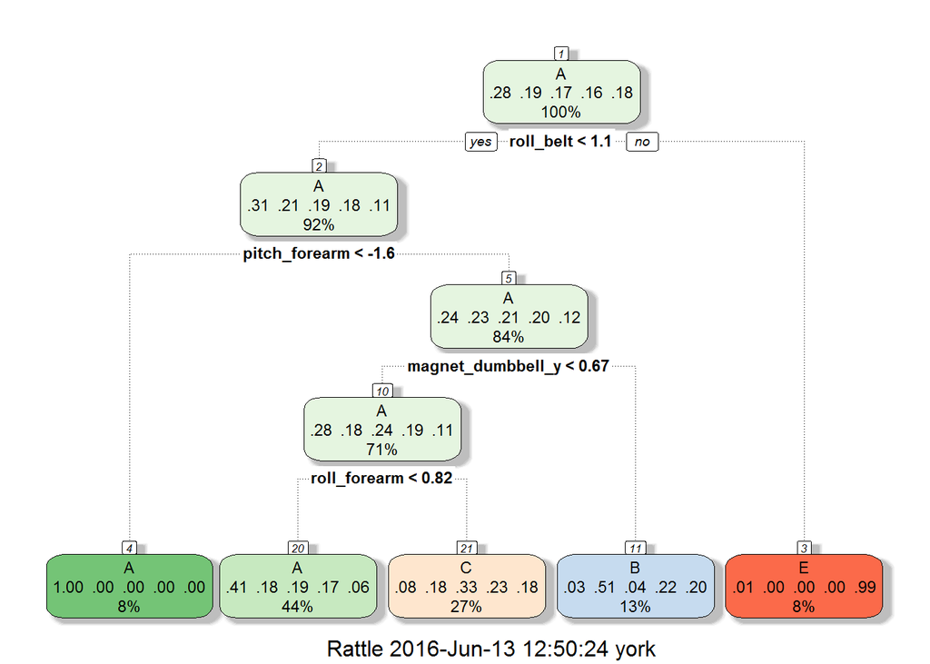

```r
fancyRpartPlot(model_rp_m$finalModel)
```

### Create Random Forest Model

Random Forest model is tried with cross validation.

```r
set.seed(123)
model_rf <- train(classe ~ ., data=training, method="rf",
                  trControl=trainControl(method = "cv", number = 4))
model_rf
```

```
## Random Forest
##
## 15699 samples
##    52 predictor
##     5 classes: 'A', 'B', 'C', 'D', 'E'
##
## No pre-processing
## Resampling: Cross-Validated (4 fold)
## Summary of sample sizes: 11775, 11775, 11774, 11773
## Resampling results across tuning parameters:
##
##   mtry  Accuracy   Kappa
##    2    0.9920379  0.9899276
##   27    0.9924837  0.9904922
##   52    0.9863049  0.9826758
##
## Accuracy was used to select the optimal model using  the largest value.
## The final value used for the model was mtry = 27.
```

This takes much longer time. But the accuracy is 99.2%, which is much better than decision tree model. The random forest model is selected.

Then apply to the testing set.

```r
pred_testing <- predict(model_rf, newdata= testing)
cm_rf <- confusionMatrix( pred_testing, testing$classe)
cm_rf
```

```
## Confusion Matrix and Statistics
##
##           Reference
## Prediction    A    B    C    D    E
##          A 1115    8    0    0    0
##          B    1  748    2    0    0
##          C    0    3  680    4    0
##          D    0    0    2  638    1
##          E    0    0    0    1  720
##
## Overall Statistics
##
##                Accuracy : 0.9944
##                  95% CI : (0.9915, 0.9965)
##     No Information Rate : 0.2845
##     P-Value [Acc > NIR] : < 2.2e-16
##
##                   Kappa : 0.9929
##  Mcnemar's Test P-Value : NA
##
## Statistics by Class:
##
##                      Class: A Class: B Class: C Class: D Class: E
## Sensitivity            0.9991   0.9855   0.9942   0.9922   0.9986
## Specificity            0.9971   0.9991   0.9978   0.9991   0.9997
## Pos Pred Value         0.9929   0.9960   0.9898   0.9953   0.9986
## Neg Pred Value         0.9996   0.9965   0.9988   0.9985   0.9997
## Prevalence             0.2845   0.1935   0.1744   0.1639   0.1838
## Detection Rate         0.2842   0.1907   0.1733   0.1626   0.1835
## Detection Prevalence   0.2863   0.1914   0.1751   0.1634   0.1838
## Balanced Accuracy      0.9981   0.9923   0.9960   0.9957   0.9992
```

The overall accuracy on the testing set is 99.44%. The out of sample error rate is 0.0056.

Apply on the raw_testing set.

```r
pred_raw_testing <- predict(model_rf, newdata=raw_testing)
pred_raw_testing
```

```
##  [1] B A B A A E D B A A B C B A E E A B B B
## Levels: A B C D E
```

### Conclusion

The resulting prediction for the original testing data is (B A B A A E D B A A B C B A E E A B B B).